# Lab6: Work with your own point pattern data

Katarzyna Goch

2 Dec 2018

This is the report for the sixth assignment “Work with your own point pattern data” from course “Analysis of Spatio-Temporal Data”, WS 2018/19.  
Supervisor: prof. Edzer Pebesma

## Explain in less than 50 words what a spatial point pattern is, what it is composed of, and which questions we tend to ask to point pattern data.

A ’spatial point pattern’ is a dataset composed ot the particular events in their exact locations (e. g. trees in a forest), where these locations were created naturally. We tend to look for any kind of reguralities in the spatial distribution of the point pattern.

## Look for a point pattern dataset on a topic that interests you.

I would like to analyze the point dataset representing location of cities in Poland in the Mazovian Voivodeship. Data were obtained as a shapefile from National Register of Geographical Names (PRNG): http://www.gugik.gov.pl/pzgik/dane-bez-oplat/dane-z-panstwowego-rejestru-nazw-geograficznych-prng Data was updated 5th Oct 2018. Data was accessed 2nd Dec 2018.

## Try to verify whether the point pattern is completely spatial random, or whether points attract each other, or repulse each other.

```r
# Read the data
p_df <- read.csv2("mazowieckie.csv",
                header=TRUE,
                quote="\"",
                stringsAsFactors = FALSE,
                strip.white = TRUE)
pointPattern <- p_df
pointPattern$Latitude<- as.numeric(as.character(p_df$wsp_pro_Y))
pointPattern$Longitude<- as.numeric(as.character(p_df$wsp_pro_X))
coordinates(pointPattern)<-~Longitude+Latitude
proj4string(pointPattern) <- CRS("+init=epsg:2180")

# Sum up
summary(pointPattern)
```

```
## Object of class SpatialPointsDataFrame
## Coordinates:
##                min      max
## Longitude 518454.3 779445.9
## Latitude  352657.7 626664.1
## Is projected: TRUE
## proj4string :
## [+init=epsg:2180 +proj=tmerc +lat_0=0 +lon_0=19 +k=0.9993
## +x_0=500000 +y_0=-5300000 +ellps=GRS80 +towgs84=0,0,0,0,0,0,0
## +units=m +no_defs]
## Number of points: 15822
## Data attributes:
##   naz_glowna          el_rozr            szer_geo
##  Length:15822       Length:15822       Length:15822
##  Class :character   Class :character   Class :character
##  Mode  :character   Mode  :character   Mode  :character
##    dlug_geo          wsp_pro_Y          wsp_pro_X
##  Length:15822       Length:15822       Length:15822
##  Class :character   Class :character   Class :character
##  Mode  :character   Mode  :character   Mode  :character
##    panstwo              woj               powiat
##  Length:15822       Length:15822       Length:15822
##  Class :character   Class :character   Class :character
##  Mode  :character   Mode  :character   Mode  :character
##     gmina
##  Length:15822
##  Class :character
##  Mode  :character
```

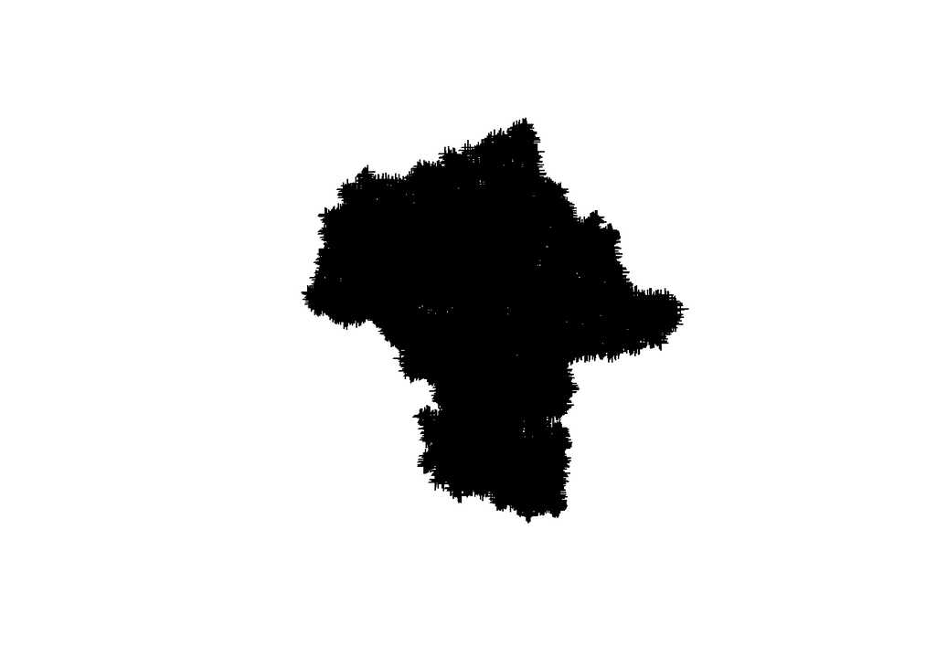

```r
# Plot
plot(pointPattern, cex=1)
```

[output not shown]

## Compute a density map of the point pattern.

```r
# Define the observation window
## Load in the voivodeship boundry nodes dataframe
b_df <- read.csv2("my_boundary.csv",
                header=TRUE,
                quote="\"",
                stringsAsFactors = FALSE,
                strip.white = TRUE)
## Drop ID column
b_df$my_id <- NULL


myWindow = owin(poly=list(x=b_df$Lon,y=b_df$Lat))

# Create a planar point pattern
myPPP = ppp(as.numeric(as.character(p_df$wsp_pro_X)), as.numeric(as.character(p_df$wsp_pro_Y)), window = myWindow)
```

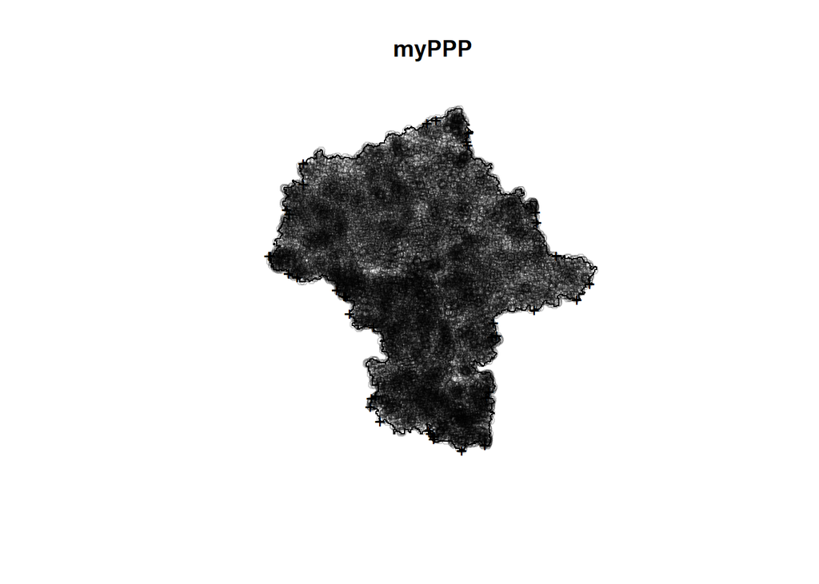

```r
plot(myPPP)
```

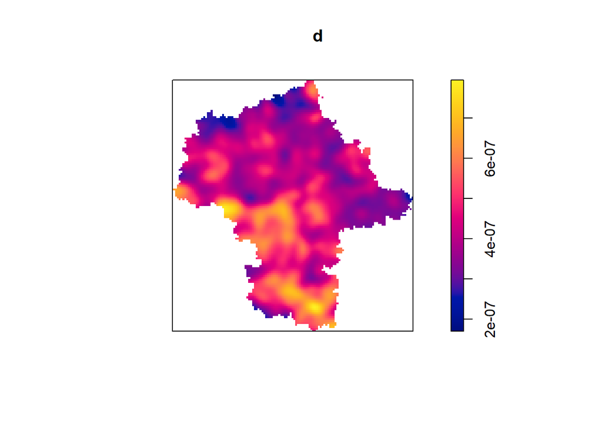

```r
d <- density.ppp(myPPP,sigma = bw.ppl(myPPP))
plot(d)
```

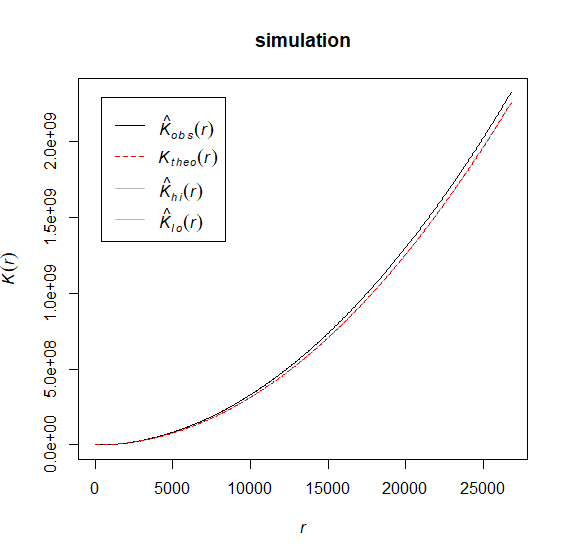

```r
# Run Kest simulation
# simulation <- envelope(myPPP, Kest, 10) <== ~2 hours
# plot(simulation)
```

## What is the unit of measurement of the values shown in this density map?

It’s the number of points around a given location divided by the given area. The unit being used here is [1/m2].